# math380hw1

Lin

2015-05-28

# 1.1 - Examine relative windiness

Are some cities more windy than others?  
Provided data contains the average wind speeds (in miles per hour) for 45 U.S. cities  
8.9, 12.4, 8.6, 11.3, 9.2, 8.8, 35.1, 6.2, 7.0, 7.1, 11.8, 10.7, 7.6, 9.1, 9.2, 8.2, 9.0, 8.7, 9.1, 10.9, 10.3, 9.6, 7.8, 11.5, 9.3, 7.8, 8.8, 8.8, 12.7, 8.4, 7.8, 5.7, 10.5, 10.5, 9.6, 8.9, 10.2, 10.3, 7.7, 10.6, 8.3, 8.8, 9.5, 8.8, 9.4

```r
windVec = c(8.9, 12.4, 8.6, 11.3, 9.2, 8.8, 35.1, 6.2, 7.0,
7.1, 11.8, 10.7, 7.6, 9.1, 9.2, 8.2, 9.0, 8.7,
9.1, 10.9, 10.3, 9.6, 7.8, 11.5, 9.3, 7.8, 8.8,
8.8, 12.7, 8.4, 7.8, 5.7, 10.5, 10.5, 9.6, 8.9,
10.2, 10.3, 7.7, 10.6, 8.3, 8.8, 9.5, 8.8, 9.4)
windVec
```

```
##  [1]  8.9 12.4  8.6 11.3  9.2  8.8 35.1  6.2  7.0  7.1 11.8 10.7  7.6  9.1
## [15]  9.2  8.2  9.0  8.7  9.1 10.9 10.3  9.6  7.8 11.5  9.3  7.8  8.8  8.8
## [29] 12.7  8.4  7.8  5.7 10.5 10.5  9.6  8.9 10.2 10.3  7.7 10.6  8.3  8.8
## [43]  9.5  8.8  9.4
```

The value 35.1 was recorded at Mt. Washington, New Hampshire. Does the geography of that city explain the magnitude of its average wind speed?

```r
windVecLessOutlier = windVec[-7]
length(windVec)
```

```
## [1] 45
```

```r
length(windVecLessOutlier)
```

```
## [1] 44
```

```r
mean(windVec)
```

```
## [1] 9.788889
```

```r
mean(windVecLessOutlier)
```

```
## [1] 9.213636
```

```r
median(windVec)
```

```
## [1] 9.1
```

```r
median(windVecLessOutlier)
```

```
## [1] 9.05
```

Construct a relative frequency histogram for these data. (Choose the class boundaries without including the value 35.1 in the range of values.)

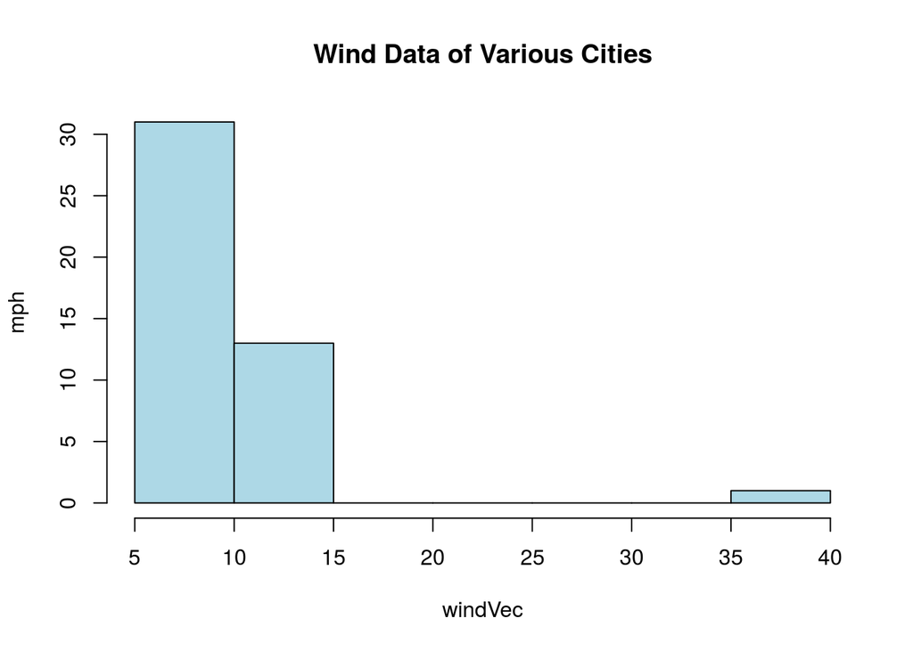

```r
hist(windVec, col='lightblue', ylab='mph', main='Wind Data of Various Cities')
```

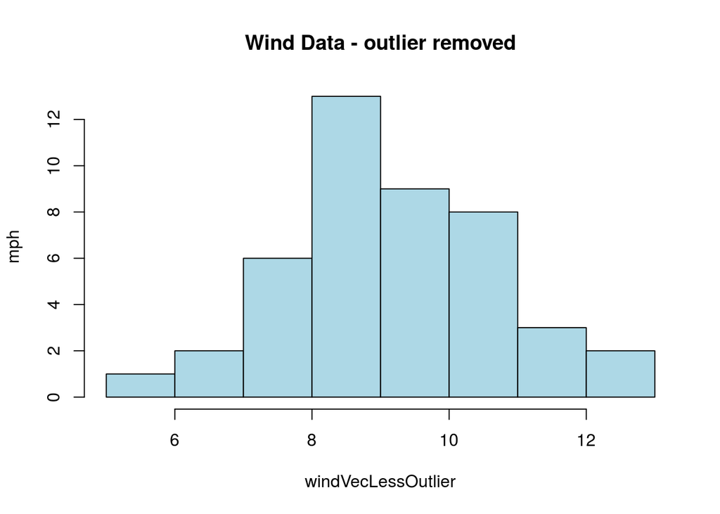

```r
hist(windVecLessOutlier, col='lightblue', ylab='mph', main='Wind Data - outlier removed')
```

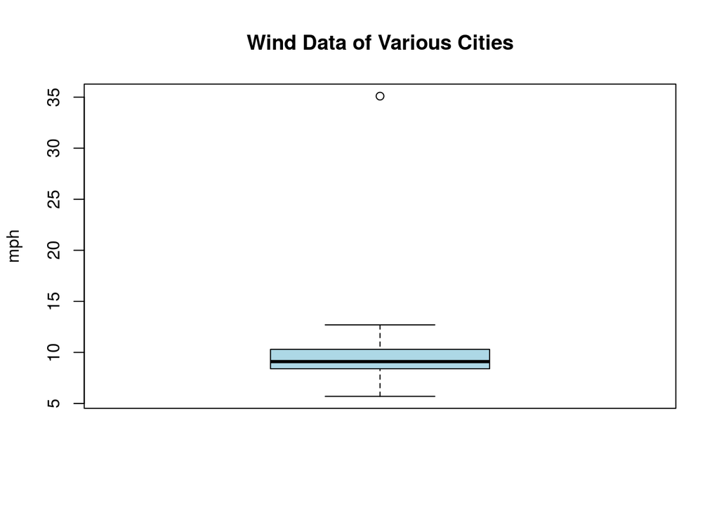

```r
boxplot(windVec, col='lightblue', ylab="mph", main='Wind Data of Various Cities')
```

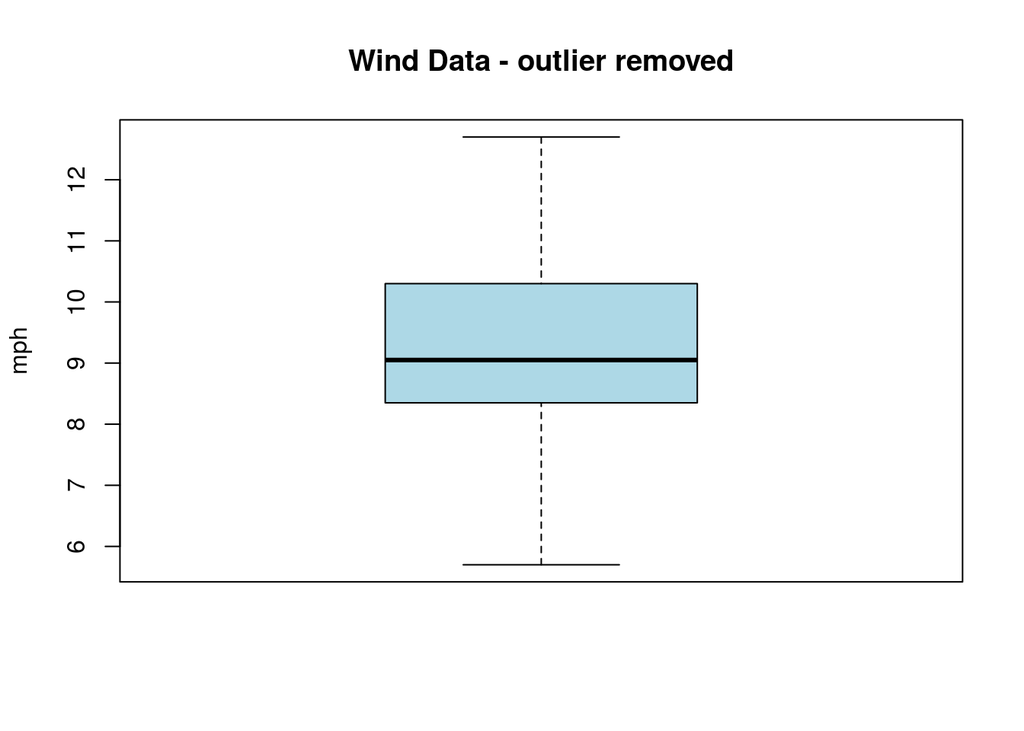

```r
boxplot(windVecLessOutlier, col='lightblue', ylab="mph", main='Wind Data - outlier removed')
```

What about Chicago (at 10.3 mph) – how do other cities stack up in terms of windiness?

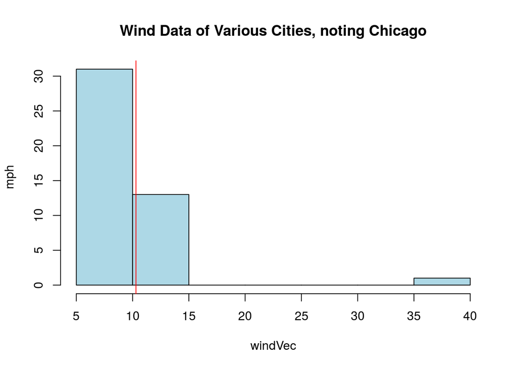

```r
Chicago=10.3
hist(windVec, col='lightblue', ylab='mph', main='Wind Data of Various Cities, noting Chicago')
abline(v=Chicago, col='red')
```

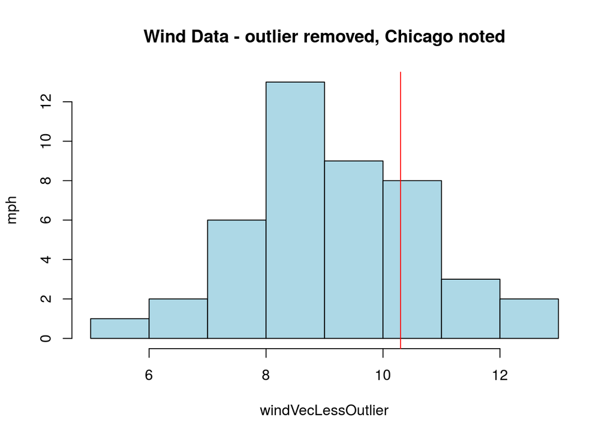

```r
hist(windVecLessOutlier, col='lightblue', ylab="mph", main='Wind Data - outlier removed, Chicago noted')
abline(v=Chicago, col='red')
```

The average wind speed for Chicago is 10.3 miles per hour. What percentage of the cities have average wind speeds in excess of Chicago’s?

```r
windierThanChicago = which(windVec>Chicago)
propWindierThanChicago = length(windierThanChicago)/length(windVec)
calmerThanChicago = which(windVec<=Chicago)
propCalmerThanChicago = length(calmerThanChicago)/length(windVec)
propWindierThanChicago; propCalmerThanChicago
```

```
## [1] 0.2444444
```

```
## [1] 0.7555556
```

# Violin Plotting

A violin plot is a combination of a boxplot and a kernel density plot, and will illustrate the various contributions.

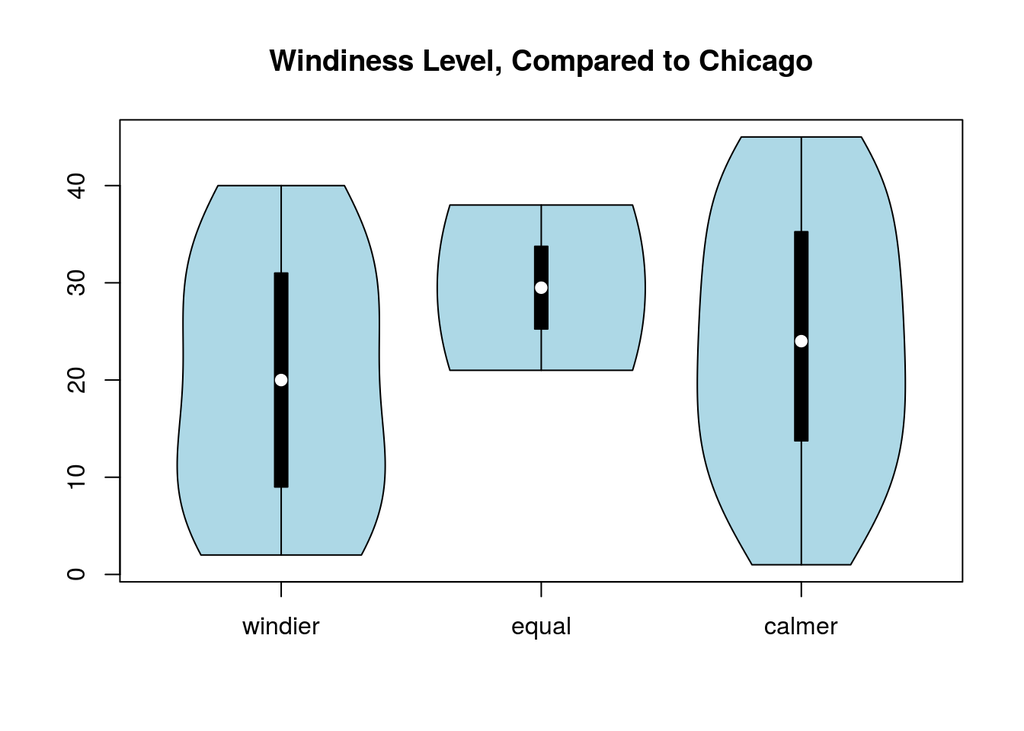

```r
library('vioplot')
calmerThanChicago = which(windVec<Chicago)
equalToChicago = which(windVec==Chicago)
vioplot(windierThanChicago, equalToChicago, calmerThanChicago, names = c('windier', 'equal', 'calmer'), col='lightblue')
title("Windiness Level, Compared to Chicago")
```

# Bagplotting

Bagplots are a bivariate take on the univariate boxplot. The bag contains 50% of all points. The bivariate median is approximated. The fence separates points in the fence from points outside. Outliers are displayed.  
This is not a real good use of bagplot … only for fun.

```r
library('aplpack')
```

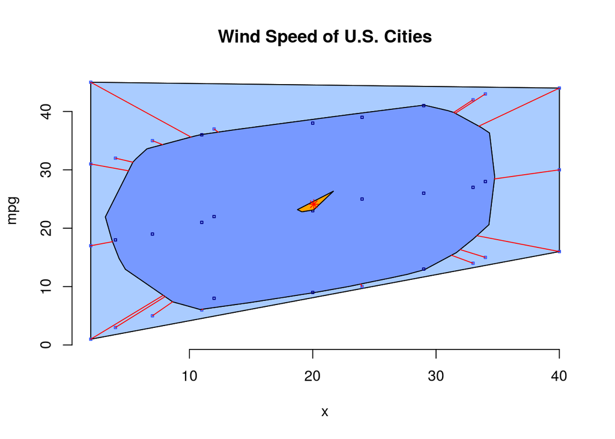

```r
bagplot(which(windVec>10.3), which(windVec<=10.3), ylab='mpg', show.whiskers=T, main='Wind Speed of U.S. Cities', pch=22)
```